# Lab01 - Parte 1

Caio Oliveira

May 19, 2017

# Laboratório 1, Parte 1: Nossa pergunta

## Tema: Análise dos dados do IMDB

….

### Tratamento inicial dos dados

#### Nesse primeiro laboratório tratamos de analisar os dados sobre séries de TV. Dados esses provenientes do IMDB que podem ser encontrados [aqui](https://raw.githubusercontent.com/nazareno/imdb-series/master/data/series_from_imdb.csv).

#### Como o professor deixou em aberto quais das séries poderiamos usar para fazer o estudo, eu escolhi minhas séries favoritas atualmente, que são: Sense8, Daredevil, Gotham, 13 Reasons Why e House of Cards.

```r
library(dplyr)
```

```r
library(ggplot2)


setwd("~/data-analysis-2/ad1/lab1")
data <-  read.csv("series_from_imdb.csv")
a <- data %>% filter(series_name %in% c("House of Cards", "Sense8", "13 Reasons Why", "Daredevil", "Gotham"))

series <- data.frame(a$UserRating, a$series_name)
series <- na.omit(series)

colnames(series)[1] <- "rating"
colnames(series)[2] <- "nome"
```

….

### Qual das séries que você escolheu é mais bem avaliada no IMDB? A diferença é grande? Pequena?

#### Para responder essa pergunta usei um gráfico de barras para as séries. A série mais bem avaliada é Daredevil com uma diferença pouca para Sense8 que é a segunda melhor avaliada. Que não chega a ser nem 0.5 de diferença

```r
series %>%
  arrange((rating)) %>%
  group_by(nome)
```

```
## Source: local data frame [176 x 2]
## Groups: nome [5]
##
##    rating           nome
##     <dbl>         <fctr>
## 1     7.5         Sense8
## 2     7.9 House of Cards
## 3     7.9         Gotham
## 4     7.9         Gotham
## 5     7.9         Gotham
## 6     8.0         Sense8
## 7     8.0         Gotham
## 8     8.0         Gotham
## 9     8.0         Gotham
## 10    8.1 House of Cards
## # ... with 166 more rows
```

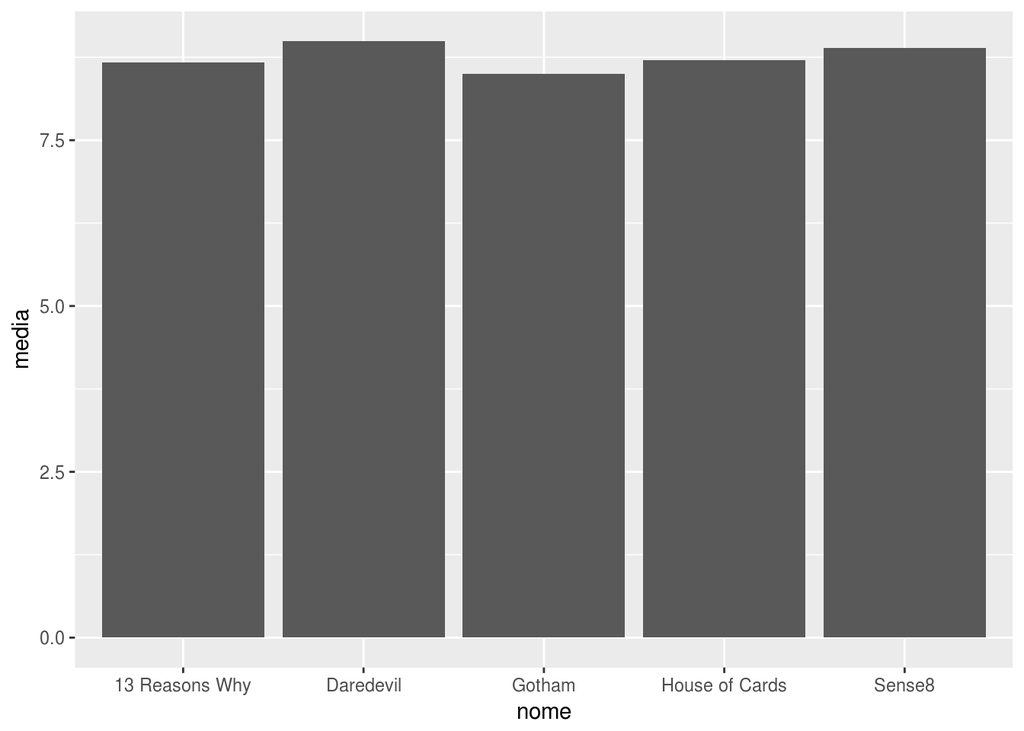

```r
medias <- series %>%
  arrange((rating)) %>%
  group_by(nome) %>%
  summarise(media = mean(rating))


g <- ggplot(medias, aes(nome,media))
g + geom_col()
```

….

### Qual das séries que você escolheu tem episódios de qualidade mais irregular segundo o IMDB? A diferença é grande? Pequena?

#### Para responder a essas perguntas usei dois tipos de gráficos que ajudam bastante a vermos variação e discrepância de valores, sendo eles: Boxplot e Violin Plot

#### Primeiramente para o boxplot podemos ver as medianas das séries bem parecidas, mas quando olhamos para o traço que representa o range de valores Sense8 aparece com o maior dentre todos, o que indica que tem uma variação maior de notas para os episódios, tendo alguns deles sido bem avaliados e outros nem tanto. O comportamento se parece com o de House of Cards, entretanto este não possui outliers. Mesmo assim a diferença (desse ponto de vista) é pequena.

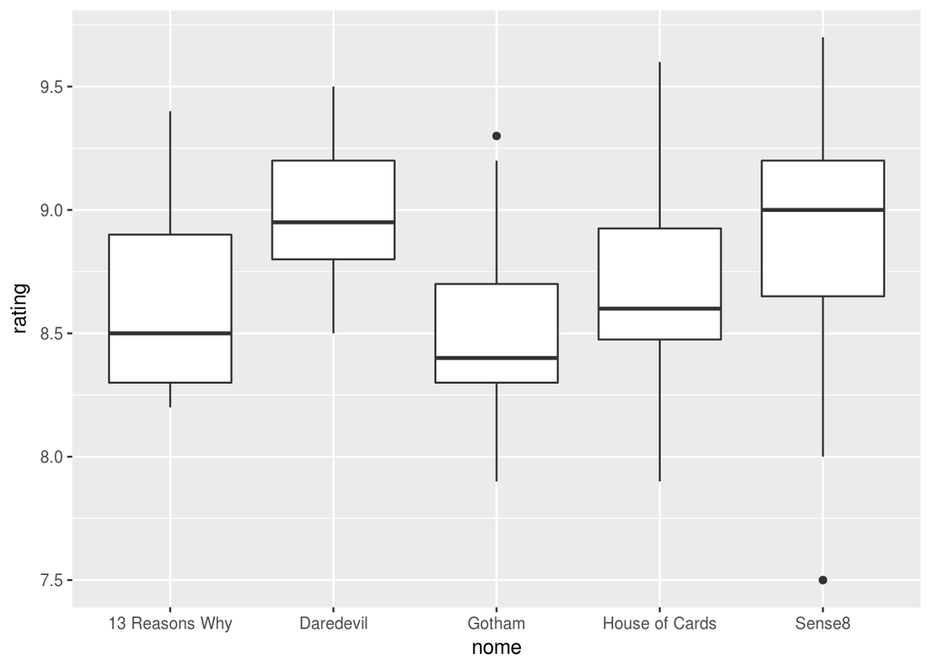

```r
boxplot <- ggplot(series, aes(nome,rating), size = 4) +
  geom_boxplot(size = 0.5) +
  scale_x_discrete()
boxplot
```

….

#### Analisando agora o Violin Plot podemos ver a concentração de pontos, ou seja, qual a pontuação que **geralmente** as pessoas votam. Podemos ver aqui que no caso de Sense8 as pessoas tendem a dar boas notas para os episódios apesar da distribuição irregular.

#### E notamos um comportamento quase identico entre House of Cards, 13 Reasons Why e Gotham, sendo este ultimo com notas um pouco menores mas a distribuição muito parecida entre essas séries.

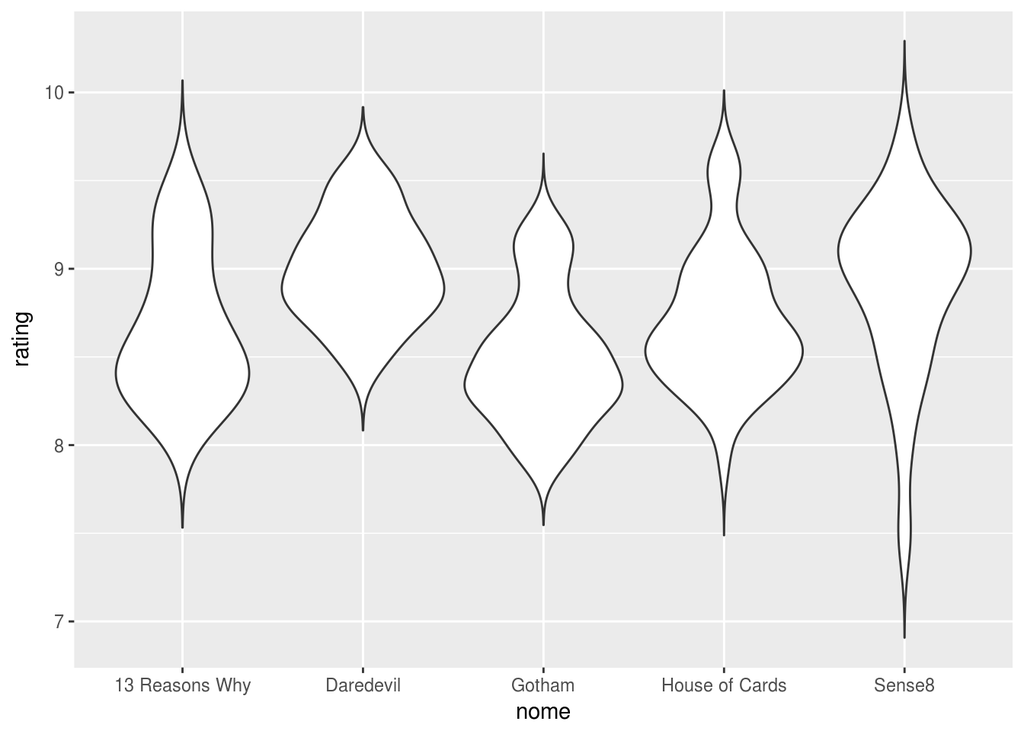

```r
p <- ggplot(series, aes(x=nome, y=rating)) +
  geom_violin(trim=FALSE)
p
```